# Urban Trait Predictors for Pigeons

```r
library(dplyr)
library(purrr)
library(tidyverse)
library(tidyr)

library(corrplot)
library(phytools)
```

## Read in data exported from bigquery

```r
all_columbidae_presence = read_csv('../../data/bigquery/columbidae_jetz__urban_locations.csv')
head(all_columbidae_presence)
```

| city_id | city_name | jetz_scientific_name | present_in_city | season_code | season | origin_code | origin |
| --- | --- | --- | --- | --- | --- | --- | --- |
| 1 | Honolulu | Stigmatopelia_chinensis | FALSE | 1 | Resident | 3 | Introduced |
| 514 | Cali | Columbina_passerina | FALSE | 1 | Resident | 1 | Native |
| 514 | Cali | Columbina_talpacoti | TRUE | 1 | Resident | 1 | Native |
| 514 | Cali | Geotrygon_montana | FALSE | 1 | Resident | 1 | Native |
| 514 | Cali | Claravis_mondetoura | FALSE | 1 | Resident | 1 | Native |
| 514 | Cali | Leptotila_plumbeiceps | FALSE | 1 | Resident | 1 | Native |

# Trait Data

De-duplicate avonet morphology using mean

```r
source("../../data/third_party/columbidae_jetz__avonet.R")
avonet_jetz = avonet_in_jetz_taxonomy()
head(avonet_jetz)
```

| jetz_scientific_name | beak_length | beak_width | beak_depth | tail_length | wing_length | tarsus_length | trophic_niche | habitat | habitat_density | primary_lifestyle | range_size | mass |
| --- | --- | --- | --- | --- | --- | --- | --- | --- | --- | --- | --- | --- |
| Alectroenas_madagascariensis | 17.5 | 4.10 | 4.2 | 81.5 | 171 | 22.3 | Frugivore | Forest | 2 | Insessorial | 311715 | 173.0 |
| Aplopelia_larvata | 21.7 | 3.30 | 3.7 | 92.9 | 143 | 26.0 | Granivore | Forest | 2 | Terrestrial | 2621499 | 155.0 |
| Caloenas_nicobarica | 30.7 | 5.40 | 7.7 | 98.8 | 259 | 43.7 | Omnivore | Forest | 1 | Terrestrial | 475641 | 537.9 |
| Chalcophaps_indica | 21.8 | 2.95 | 4.1 | 85.5 | 148 | 25.9 | Omnivore | Forest | 1 | Generalist | 5343787 | 136.5 |
| Chalcophaps_stephani | 20.7 | 2.60 | 3.8 | 84.4 | 136 | 24.8 | Omnivore | Forest | 3 | Generalist | 866814 | 129.0 |
| Claravis_godefrida | 17.4 | 3.40 | 3.7 | 81.8 | 118 | 22.1 | Granivore | Forest | 1 | Terrestrial | 148132 | 43.5 |

## Evolutionary Age of Pigeons

Phylogenetic maximum clade tree based on a set of trees from Jetz et al. (2012) using the Hacket et al. (2008) backbone. Trim tree to just species within our urban communities

```r
all_avian_species_tree <- read.tree("../../data/third_party/phylogeny_jetz__stage2_hackett_mcc_no_neg.tre")
columbidae_tree <- ladderize(drop.tip(all_avian_species_tree, setdiff(all_avian_species_tree$tip.label, all_columbidae_presence$jetz_scientific_name)))
```

Find the length of the final branch for each pigeon in the tree

```r
terminal_branch_length = columbidae_tree$edge.length[columbidae_tree$edge[, 2] %in% 1:Ntip(columbidae_tree)]
tips <- columbidae_tree$edge[columbidae_tree$edge[, 2] %in%  1:Ntip(columbidae_tree), 2]
names(terminal_branch_length) = columbidae_tree$tip.label[tips]

columbidae_branch_lengths = as.data.frame(terminal_branch_length)
columbidae_branch_lengths$jetz_scientific_name = rownames(columbidae_branch_lengths)
rownames(columbidae_branch_lengths) = NULL
head(columbidae_branch_lengths)
```

|  | terminal_branch_length | jetz_scientific_name |
| --- | --- | --- |
| 1 | 1.43 | Columba_livia |
| 2 | 1.43 | Columba_rupestris |
| 3 | 2.78 | Columba_eversmanni |
| 4 | 4.50 | Columba_unicincta |
| 5 | 6.53 | Columba_oenas |
| 6 | 2.66 | Columba_guinea |

# Build analysis dataset

```r
columbidae_presence_tmp = right_join(all_columbidae_presence, avonet_jetz)
columbidae_presence_tmp = right_join(columbidae_presence_tmp, columbidae_branch_lengths)
columbidae_presence = columbidae_presence_tmp[,c('present_in_city',  'season', 'origin', 'trophic_niche', 'habitat', 'habitat_density', 'primary_lifestyle', 'terminal_branch_length')]
head(columbidae_presence)
```

| present_in_city | season | origin | trophic_niche | habitat | habitat_density | primary_lifestyle | terminal_branch_length |
| --- | --- | --- | --- | --- | --- | --- | --- |
| FALSE | Resident | Introduced | Granivore | Woodland | 3 | Terrestrial | 6.93 |
| FALSE | Resident | Native | Omnivore | Shrubland | 2 | Terrestrial | 3.58 |
| TRUE | Resident | Native | Granivore | Human Modified | 3 | Terrestrial | 1.23 |
| FALSE | Resident | Native | Omnivore | Forest | 1 | Terrestrial | 10.48 |
| FALSE | Resident | Native | Granivore | Forest | 1 | Terrestrial | 4.02 |
| FALSE | Resident | Native | Granivore | Forest | 1 | Terrestrial | 2.99 |

# Presence Analysis

This analysis is sensitive to response of species that occur in a large number of regional pools particularly urban exploiters (that occur in most cities) or urban avoiders (that appear in few cities) - the presence/absense of these species with have a larger impact on this result that other species.

## Season

```r
table(columbidae_presence$present_in_city, columbidae_presence$season)
```

```
        Breeding Non-Breeding Passage Resident
  FALSE      178           94      16     1888
  TRUE        45            9       0     1044
```

```r
chisq_season = chisq.test(table(columbidae_presence$present_in_city, columbidae_presence$season))
chisq_season
```

```
    Pearson's Chi-squared test

data:  table(columbidae_presence$present_in_city, columbidae_presence$season)
X-squared = 60, df = 3, p-value = 6e-13
```

```r
round(chisq_season$residuals, 2)
```

```
        Breeding Non-Breeding Passage Resident
  FALSE     2.45         3.09    1.65    -1.37
  TRUE     -3.44        -4.35   -2.32     1.94
```

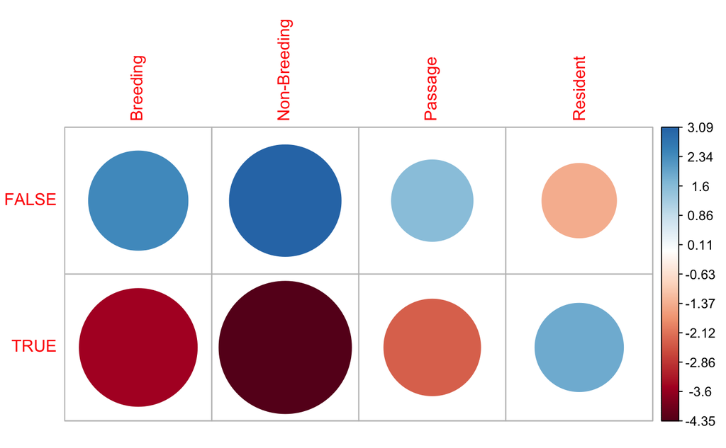

```r
corrplot(chisq_season$residuals, is.cor = FALSE)
```

## Origin

```r
table(columbidae_presence$present_in_city, columbidae_presence$origin)
```

```
        Introduced Native
  FALSE         21   2155
  TRUE          83   1015
```

```r
chisq_origin = chisq.test(table(columbidae_presence$present_in_city, columbidae_presence$origin))
chisq_origin
```

```
    Pearson's Chi-squared test with Yates' continuity correction

data:  table(columbidae_presence$present_in_city, columbidae_presence$origin)
X-squared = 101, df = 1, p-value <2e-16
```

```r
round(chisq_origin$residuals, 2)
```

```
        Introduced Native
  FALSE      -5.79   1.05
  TRUE        8.15  -1.48
```

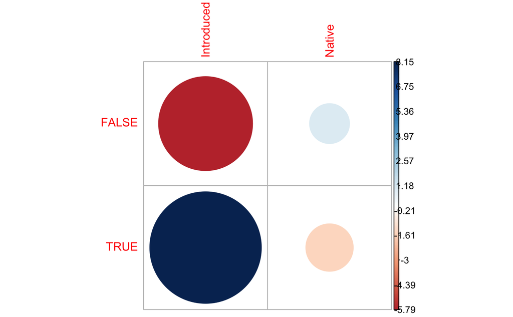

```r
corrplot(chisq_origin$residuals, is.cor = FALSE)
```

## Habitat

```r
table(columbidae_presence$present_in_city, columbidae_presence$habitat)
```

```
        Desert Forest Grassland Human Modified Rock Shrubland Woodland
  FALSE     22   1009        10            183    9       255      685
  TRUE       0    100         7            648    1       151      191
```

```r
chisq_habitat = chisq.test(table(columbidae_presence$present_in_city, columbidae_presence$habitat))
chisq_habitat
```

```
    Pearson's Chi-squared test

data:  table(columbidae_presence$present_in_city, columbidae_presence$habitat)
X-squared = 1106, df = 6, p-value <2e-16
```

```r
round(chisq_habitat$residuals, 2)
```

```
        Desert Forest Grassland Human Modified   Rock Shrubland Woodland
  FALSE   1.93  10.03     -0.38         -15.71   0.91     -0.90     4.27
  TRUE   -2.72 -14.11      0.54          22.10  -1.29      1.26    -6.01
```

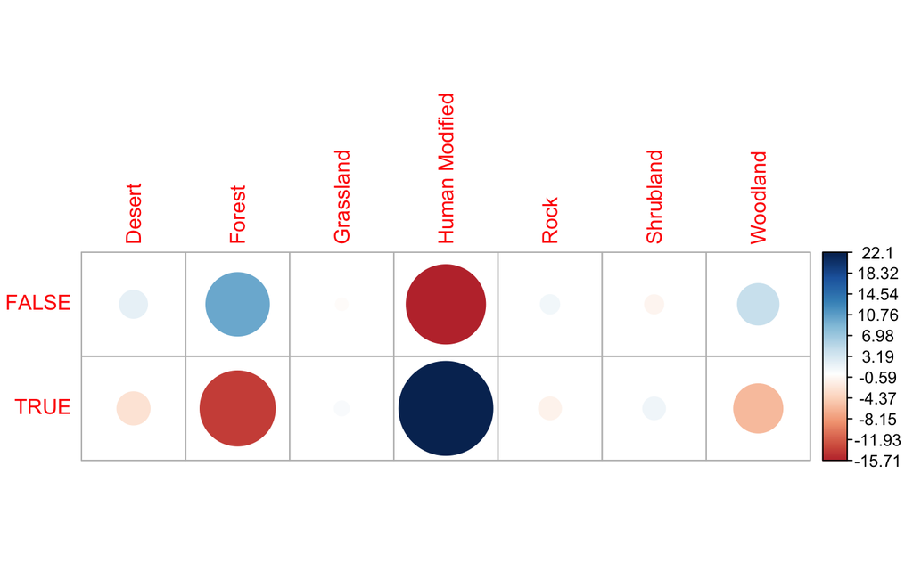

```r
corrplot(chisq_habitat$residuals, is.cor = FALSE)
```

## Habitat Density

```r
table(columbidae_presence$present_in_city, columbidae_presence$habitat_density)
```

```
          1   2   3
  FALSE 520 945 711
  TRUE   40 289 769
```

```r
chisq_habitat_density = chisq.test(table(columbidae_presence$present_in_city, columbidae_presence$habitat_density))
chisq_habitat_density
```

```
    Pearson's Chi-squared test

data:  table(columbidae_presence$present_in_city, columbidae_presence$habitat_density)
X-squared = 457, df = 2, p-value <2e-16
```

```r
round(chisq_habitat_density$residuals, 2)
```

```
             1      2      3
  FALSE   7.66   4.36  -8.69
  TRUE  -10.79  -6.14  12.24
```

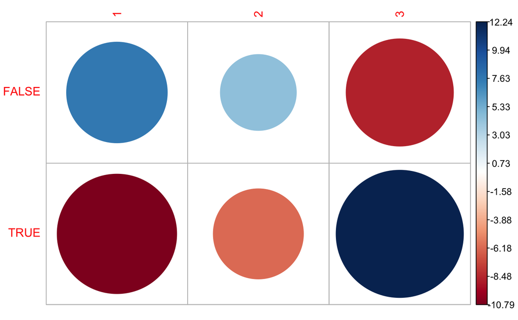

```r
corrplot(chisq_habitat_density$residuals, is.cor = FALSE)
```

## Trophic Guild

```r
table(columbidae_presence$present_in_city, columbidae_presence$trophic_niche)
```

```
        Frugivore Granivore Omnivore
  FALSE       599      1007      570
  TRUE         76       694      328
```

```r
chisq_trophic = chisq.test(table(columbidae_presence$present_in_city, columbidae_presence$trophic_niche))
chisq_trophic
```

```
    Pearson's Chi-squared test

data:  table(columbidae_presence$present_in_city, columbidae_presence$trophic_niche)
X-squared = 194, df = 2, p-value <2e-16
```

```r
round(chisq_trophic$residuals, 2)
```

```
        Frugivore Granivore Omnivore
  FALSE      7.10     -3.67    -1.10
  TRUE      -9.99      5.17     1.55
```

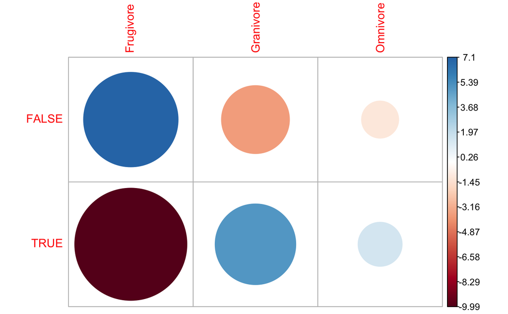

```r
corrplot(chisq_trophic$residuals, is.cor = FALSE)
```

## Primary Lifestyle

```r
table(columbidae_presence$present_in_city, columbidae_presence$primary_lifestyle)
```

```
        Generalist Insessorial Terrestrial
  FALSE        146         622        1408
  TRUE          70          76         952
```

```r
chisq_primary_lifestyle = chisq.test(table(columbidae_presence$present_in_city, columbidae_presence$primary_lifestyle))
chisq_primary_lifestyle
```

```
    Pearson's Chi-squared test

data:  table(columbidae_presence$present_in_city, columbidae_presence$primary_lifestyle)
X-squared = 210, df = 2, p-value <2e-16
```

```r
round(chisq_primary_lifestyle$residuals, 2)
```

```
        Generalist Insessorial Terrestrial
  FALSE       0.20        7.34       -4.05
  TRUE       -0.29      -10.33        5.71
```

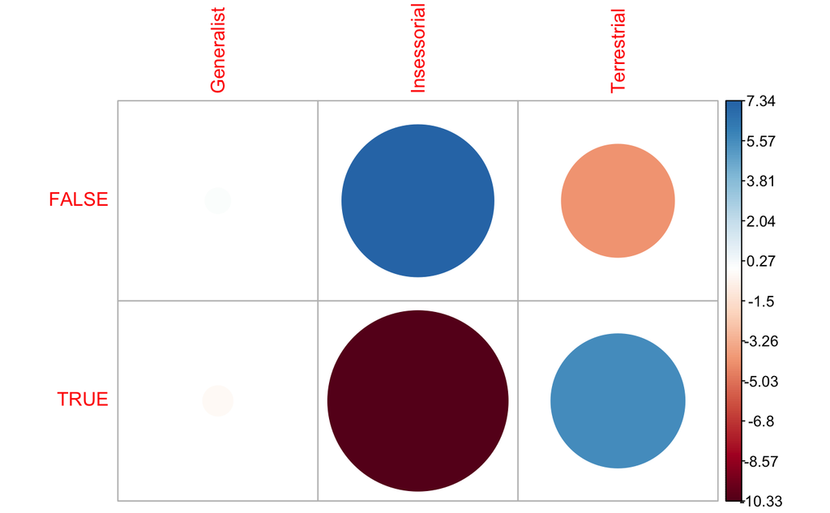

```r
corrplot(chisq_primary_lifestyle$residuals, is.cor = FALSE)
```

## Evolutionary Age of Species

```r
print('Mean evolutionary age for species in cities')
```

```
[1] "Mean evolutionary age for species in cities"
```

```r
mean(columbidae_presence$terminal_branch_length[columbidae_presence$present_in_city])
```

```
[1] 3.43
```

```r
print('Mean evolutionary age for species NOT in cities')
```

```
[1] "Mean evolutionary age for species NOT in cities"
```

```r
mean(columbidae_presence$terminal_branch_length[!columbidae_presence$present_in_city])
```

```
[1] 5.77
```

```r
wilcox.test(columbidae_presence$terminal_branch_length[columbidae_presence$present_in_city], columbidae_presence$terminal_branch_length[!columbidae_presence$present_in_city])
```

```
    Wilcoxon rank sum test with continuity correction

data:  columbidae_presence$terminal_branch_length[columbidae_presence$present_in_city] and columbidae_presence$terminal_branch_length[!columbidae_presence$present_in_city]
W = 7e+05, p-value <2e-16
alternative hypothesis: true location shift is not equal to 0
```

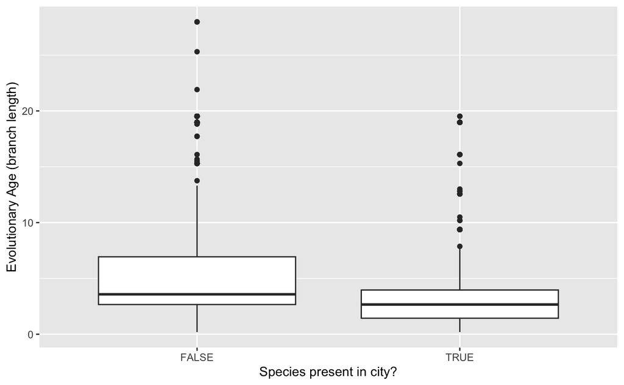

```r
ggplot(columbidae_presence, aes(x = present_in_city, y = terminal_branch_length)) +
  geom_boxplot() +
  xlab('Species present in city?') + ylab('Evolutionary Age (branch length)')
```

# Urban Tolerance Analysis

This analysis is sensitive to response of species that occur in a small number of regional pools and are urban adapters, e.g. may occur in cities but are not either prevalent or totally absent. e.g. a species in only 1 regional pool can only have a tolerance of 0 or 1, and a species in only 2 regional pools can only have a tolerance of 0 (0/2), 0.5 (1/2), or 1 (2/2).

## Data sets

For analysis not dependent on whether species in range

```r
columbidae_urban_tolerance_tmp = all_columbidae_presence %>% group_by(jetz_scientific_name) %>% summarise(regional_pools = n(), urban_pools = sum(present_in_city), urban_tolerance = sum(present_in_city) / n())
columbidae_urban_tolerance_tmp = right_join(columbidae_urban_tolerance_tmp, avonet_jetz)
columbidae_urban_tolerance_tmp = right_join(columbidae_urban_tolerance_tmp, columbidae_branch_lengths)
columbidae_tolerance = columbidae_urban_tolerance_tmp[,c('jetz_scientific_name', 'urban_tolerance',  'regional_pools', 'urban_pools', 'trophic_niche', 'habitat', 'habitat_density', 'primary_lifestyle', 'terminal_branch_length')]
head(columbidae_tolerance)
```

| jetz_scientific_name | urban_tolerance | regional_pools | urban_pools | trophic_niche | habitat | habitat_density | primary_lifestyle | terminal_branch_length |
| --- | --- | --- | --- | --- | --- | --- | --- | --- |
| Alectroenas_madagascariensis | 0.0000 | 1 | 0 | Frugivore | Forest | 2 | Insessorial | 11.60 |
| Aplopelia_larvata | 0.0000 | 9 | 0 | Granivore | Forest | 2 | Terrestrial | 12.69 |
| Caloenas_nicobarica | 0.0000 | 3 | 0 | Omnivore | Forest | 1 | Terrestrial | 27.97 |
| Chalcophaps_indica | 0.0317 | 63 | 2 | Omnivore | Forest | 1 | Generalist | 19.52 |
| Claravis_godefrida | 0.0000 | 14 | 0 | Granivore | Forest | 1 | Terrestrial | 4.02 |
| Claravis_mondetoura | 0.0000 | 13 | 0 | Granivore | Forest | 1 | Terrestrial | 4.02 |

## Season

For analysis of season

```r
columbidae_urban_tolerance_seasonal_tmp = all_columbidae_presence %>% group_by(jetz_scientific_name, season) %>% summarise(regional_pools = n(), urban_pools = sum(present_in_city), urban_tolerance = sum(present_in_city) / n())
columbidae_urban_tolerance_seasonal_tmp = right_join(columbidae_urban_tolerance_seasonal_tmp, avonet_jetz)
columbidae_urban_tolerance_seasonal_tmp = right_join(columbidae_urban_tolerance_seasonal_tmp, columbidae_branch_lengths)
columbidae_urban_tolerance_seasonal = columbidae_urban_tolerance_seasonal_tmp[,c('urban_tolerance',  'season')]
head(columbidae_urban_tolerance_seasonal)
```

| urban_tolerance | season |
| --- | --- |
| 0.0000 | Resident |
| 0.0000 | Resident |
| 0.0000 | Resident |
| 0.0317 | Resident |
| 0.0000 | Resident |
| 0.0000 | Resident |

```r
kruskal.test(columbidae_urban_tolerance_seasonal$urban_tolerance ~ columbidae_urban_tolerance_seasonal$season)
```

```
    Kruskal-Wallis rank sum test

data:  columbidae_urban_tolerance_seasonal$urban_tolerance by columbidae_urban_tolerance_seasonal$season
Kruskal-Wallis chi-squared = 2, df = 3, p-value = 0.5
```

```r
pairwise.wilcox.test(columbidae_urban_tolerance_seasonal$urban_tolerance, columbidae_urban_tolerance_seasonal$season)
```

```
    Pairwise comparisons using Wilcoxon rank sum test with continuity correction

data:  columbidae_urban_tolerance_seasonal$urban_tolerance and columbidae_urban_tolerance_seasonal$season

             Breeding Non-Breeding Passage
Non-Breeding 1        -            -
Passage      1        1            -
Resident     1        1            1

P value adjustment method: holm
```

## Origin

For analysis of origin

```r
columbidae_urban_tolerance_origin_tmp = all_columbidae_presence %>% group_by(jetz_scientific_name, origin) %>% summarise(regional_pools = n(), urban_pools = sum(present_in_city), urban_tolerance = sum(present_in_city) / n())
columbidae_urban_tolerance_origin_tmp = right_join(columbidae_urban_tolerance_origin_tmp, avonet_jetz)
columbidae_urban_tolerance_origin_tmp = right_join(columbidae_urban_tolerance_origin_tmp, columbidae_branch_lengths)
columbidae_urban_tolerance_origin = columbidae_urban_tolerance_origin_tmp[,c('jetz_scientific_name', 'urban_tolerance',  'regional_pools', 'urban_pools', 'origin')]
head(columbidae_urban_tolerance_origin)
```

| jetz_scientific_name | urban_tolerance | regional_pools | urban_pools | origin |
| --- | --- | --- | --- | --- |
| Alectroenas_madagascariensis | 0.0000 | 1 | 0 | Native |
| Aplopelia_larvata | 0.0000 | 9 | 0 | Native |
| Caloenas_nicobarica | 0.0000 | 3 | 0 | Native |
| Chalcophaps_indica | 0.0317 | 63 | 2 | Native |
| Claravis_godefrida | 0.0000 | 14 | 0 | Native |
| Claravis_mondetoura | 0.0000 | 13 | 0 | Native |

Introduced species

```r
columbidae_urban_tolerance_origin[columbidae_urban_tolerance_origin$origin == 'Introduced',]
```

| jetz_scientific_name | urban_tolerance | regional_pools | urban_pools | origin |
| --- | --- | --- | --- | --- |
| Columba_livia | 1.0000 | 80 | 80 | Introduced |
| Geopelia_striata | 1.0000 | 2 | 2 | Introduced |
| Stigmatopelia_chinensis | 0.0000 | 8 | 0 | Introduced |
| Stigmatopelia_senegalensis | 0.0000 | 1 | 0 | Introduced |
| Streptopelia_roseogrisea | 0.0833 | 12 | 1 | Introduced |
| Streptopelia_tranquebarica | 0.0000 | 1 | 0 | Introduced |

Which have an overall status

```r
introduced_species_names = columbidae_urban_tolerance_origin$jetz_scientific_name[columbidae_urban_tolerance_origin$origin == 'Introduced']
columbidae_tolerance[columbidae_tolerance$jetz_scientific_name %in% introduced_species_names,]
```

| jetz_scientific_name | urban_tolerance | regional_pools | urban_pools | trophic_niche | habitat | habitat_density | primary_lifestyle | terminal_branch_length |
| --- | --- | --- | --- | --- | --- | --- | --- | --- |
| Columba_livia | 1.000 | 222 | 222 | Granivore | Human Modified | 3 | Terrestrial | 1.43 |
| Geopelia_striata | 1.000 | 11 | 11 | Granivore | Woodland | 2 | Terrestrial | 3.37 |
| Stigmatopelia_chinensis | 0.000 | 142 | 0 | Granivore | Woodland | 3 | Terrestrial | 6.93 |
| Stigmatopelia_senegalensis | 0.000 | 109 | 0 | Granivore | Woodland | 3 | Terrestrial | 6.93 |
| Streptopelia_roseogrisea | 0.143 | 14 | 2 | Granivore | Shrubland | 2 | Terrestrial | 1.72 |
| Streptopelia_tranquebarica | 0.207 | 92 | 19 | Granivore | Woodland | 2 | Terrestrial | 2.93 |

```r
wilcox.test(columbidae_urban_tolerance_origin$urban_tolerance ~ columbidae_urban_tolerance_origin$origin)
```

```
    Wilcoxon rank sum test with continuity correction

data:  columbidae_urban_tolerance_origin$urban_tolerance by columbidae_urban_tolerance_origin$origin
W = 561, p-value = 0.4
alternative hypothesis: true location shift is not equal to 0
```

```r
print("Mean tolerance of native species")
```

```
[1] "Mean tolerance of native species"
```

```r
mean(columbidae_urban_tolerance_origin$urban_tolerance[columbidae_urban_tolerance_origin$origin == 'Native'])
```

```
[1] 0.196
```

```r
print("Mean tolernace of introduced species")
```

```
[1] "Mean tolernace of introduced species"
```

```r
mean(columbidae_urban_tolerance_origin$urban_tolerance[columbidae_urban_tolerance_origin$origin != 'Native'])
```

```
[1] 0.347
```

## Habitat

```r
kruskal.test(columbidae_tolerance$urban_tolerance ~ columbidae_tolerance$habitat)
```

```
    Kruskal-Wallis rank sum test

data:  columbidae_tolerance$urban_tolerance by columbidae_tolerance$habitat
Kruskal-Wallis chi-squared = 51, df = 6, p-value = 3e-09
```

```r
pairwise.wilcox.test(columbidae_tolerance$urban_tolerance, columbidae_tolerance$habitat)
```

```
    Pairwise comparisons using Wilcoxon rank sum test with continuity correction

data:  columbidae_tolerance$urban_tolerance and columbidae_tolerance$habitat

               Desert Forest Grassland Human Modified Rock Shrubland
Forest         1.00   -      -         -              -    -
Grassland      1.00   1.00   -         -              -    -
Human Modified 1.00   7e-07  1.00      -              -    -
Rock           1.00   1.00   1.00      0.76           -    -
Shrubland      1.00   1e-06  1.00      0.78           1.00 -
Woodland       1.00   0.03   1.00      0.02           1.00 1.00

P value adjustment method: holm
```

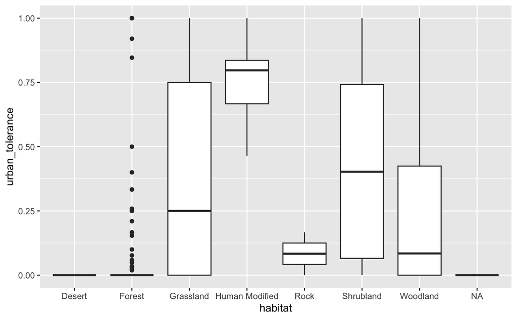

```r
ggplot(data = columbidae_tolerance, aes(x = habitat, y = urban_tolerance)) + geom_boxplot()
```

## Habitat Density

```r
kruskal.test(columbidae_tolerance$urban_tolerance ~ columbidae_tolerance$habitat_density)
```

```
    Kruskal-Wallis rank sum test

data:  columbidae_tolerance$urban_tolerance by columbidae_tolerance$habitat_density
Kruskal-Wallis chi-squared = 31, df = 2, p-value = 2e-07
```

```r
pairwise.wilcox.test(columbidae_tolerance$urban_tolerance, columbidae_tolerance$habitat_density)
```

```
    Pairwise comparisons using Wilcoxon rank sum test with continuity correction

data:  columbidae_tolerance$urban_tolerance and columbidae_tolerance$habitat_density

  1     2
2 0.002 -
3 3e-07 4e-04

P value adjustment method: holm
```

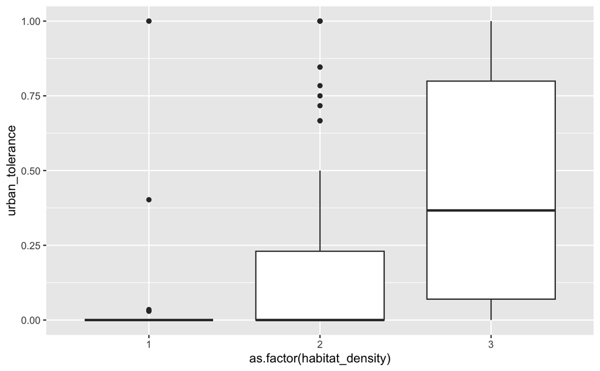

```r
ggplot(columbidae_tolerance, aes(x = as.factor(habitat_density), y = urban_tolerance)) + geom_boxplot()
```

## Trophic Guild

```r
kruskal.test(columbidae_tolerance$urban_tolerance ~ columbidae_tolerance$trophic_niche)
```

```
    Kruskal-Wallis rank sum test

data:  columbidae_tolerance$urban_tolerance by columbidae_tolerance$trophic_niche
Kruskal-Wallis chi-squared = 16, df = 2, p-value = 4e-04
```

```r
pairwise.wilcox.test(columbidae_tolerance$urban_tolerance, columbidae_tolerance$trophic_niche)
```

```
    Pairwise comparisons using Wilcoxon rank sum test with continuity correction

data:  columbidae_tolerance$urban_tolerance and columbidae_tolerance$trophic_niche

          Frugivore Granivore
Granivore 0.001     -
Omnivore  0.975     0.008

P value adjustment method: holm
```

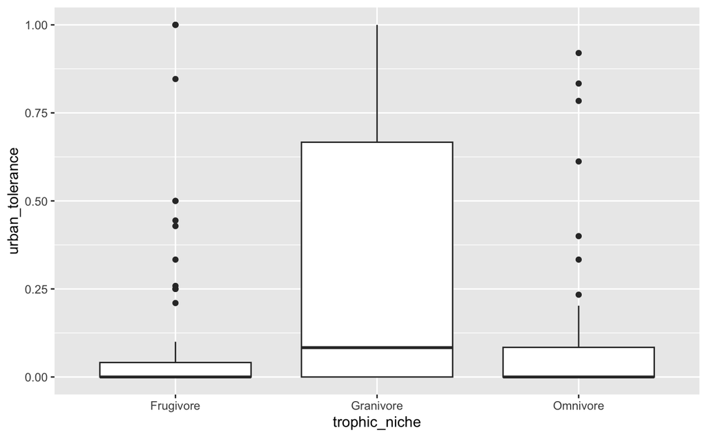

```r
ggplot(columbidae_tolerance, aes(x = trophic_niche, y = urban_tolerance)) + geom_boxplot()
```

## Primary Lifestyle

```r
kruskal.test(columbidae_tolerance$urban_tolerance ~ columbidae_tolerance$primary_lifestyle)
```

```
    Kruskal-Wallis rank sum test

data:  columbidae_tolerance$urban_tolerance by columbidae_tolerance$primary_lifestyle
Kruskal-Wallis chi-squared = 12, df = 2, p-value = 0.003
```

```r
pairwise.wilcox.test(columbidae_tolerance$urban_tolerance, columbidae_tolerance$primary_lifestyle)
```

```
    Pairwise comparisons using Wilcoxon rank sum test with continuity correction

data:  columbidae_tolerance$urban_tolerance and columbidae_tolerance$primary_lifestyle

            Generalist Insessorial
Insessorial 0.044      -
Terrestrial 0.415      0.005

P value adjustment method: holm
```

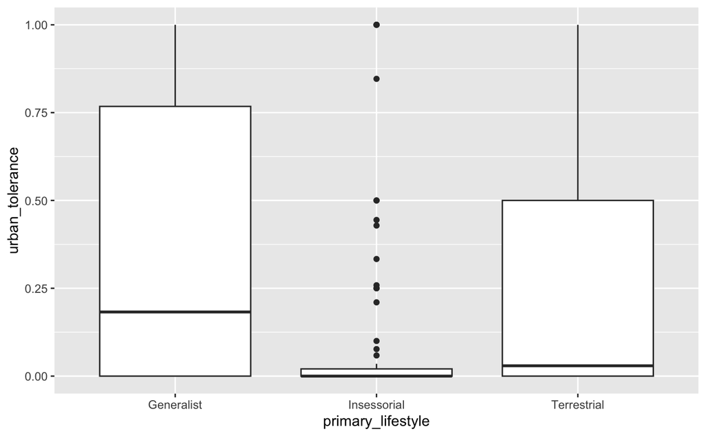

```r
ggplot(columbidae_tolerance, aes(x = primary_lifestyle, y = urban_tolerance)) + geom_boxplot()
```

## Evolutionary Age of Species

```r
summary(glm(data = columbidae_tolerance, formula = urban_tolerance ~ terminal_branch_length, family = "gaussian"))
```

```
Call:
glm(formula = urban_tolerance ~ terminal_branch_length, family = "gaussian",
    data = columbidae_tolerance)

Coefficients:
                       Estimate Std. Error t value Pr(>|t|)
(Intercept)             0.25313    0.03961    6.39  1.8e-09 ***
terminal_branch_length -0.00986    0.00507   -1.95    0.054 .
---
Signif. codes:  0 ‘***’ 0.001 ‘**’ 0.01 ‘*’ 0.05 ‘.’ 0.1 ‘ ’ 1

(Dispersion parameter for gaussian family taken to be 0.101)

    Null deviance: 16.311  on 159  degrees of freedom
Residual deviance: 15.930  on 158  degrees of freedom
AIC: 90.95

Number of Fisher Scoring iterations: 2
```

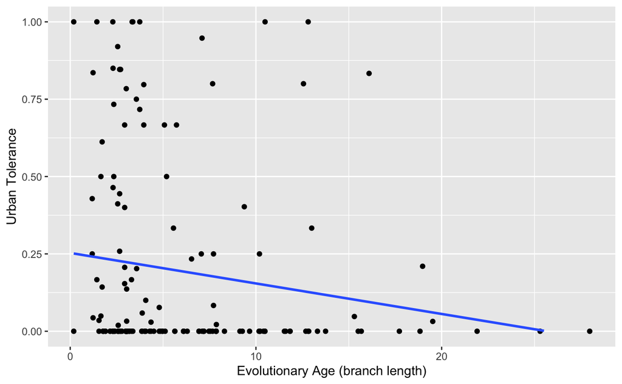

```r
ggplot(columbidae_tolerance, aes(x = terminal_branch_length, y = urban_tolerance)) +
  geom_point() +
  geom_smooth(formula = "y ~ x", method="glm", se=F) +
  ylab('Urban Tolerance') + xlab('Evolutionary Age (branch length)') + ylim(c(0, 1))
```